# Analyse en Composantes Principales

Jeu de données decathlon

Ce jeu de données contient 41 individus et 10 variables.

### 2. Distribution de l’inertie

L’inertie des axes factoriels indique d’une part si les variables sont structurées et suggère d’autre part le nombre judicieux de composantes principales à étudier.

Les 2 premiers axes de l’ ACP expriment **50.09%** de l’inertie totale du jeu de données ; cela signifie que 50.09% de la variabilité totale du nuage des individus (ou des variables) est représentée dans ce plan. C’est un pourcentage assez important, et le premier plan représente donc convenablement la variabilité contenue dans une grande part du jeu de données actif. Cette valeur est supérieure à la valeur référence de **37.74%**, la variabilité expliquée par ce plan est donc significative (cette intertie de référence est le quantile 0.95 de la distribution des pourcentages d’inertie obtenus en simulant 1371 jeux de données aléatoires de dimensions comparables sur la base d’une distribution normale).

Du fait de ces observations, il serait tout de même probablement préférable de considérer également dans l’analyse les dimensions supérieures ou égales à la troisième.

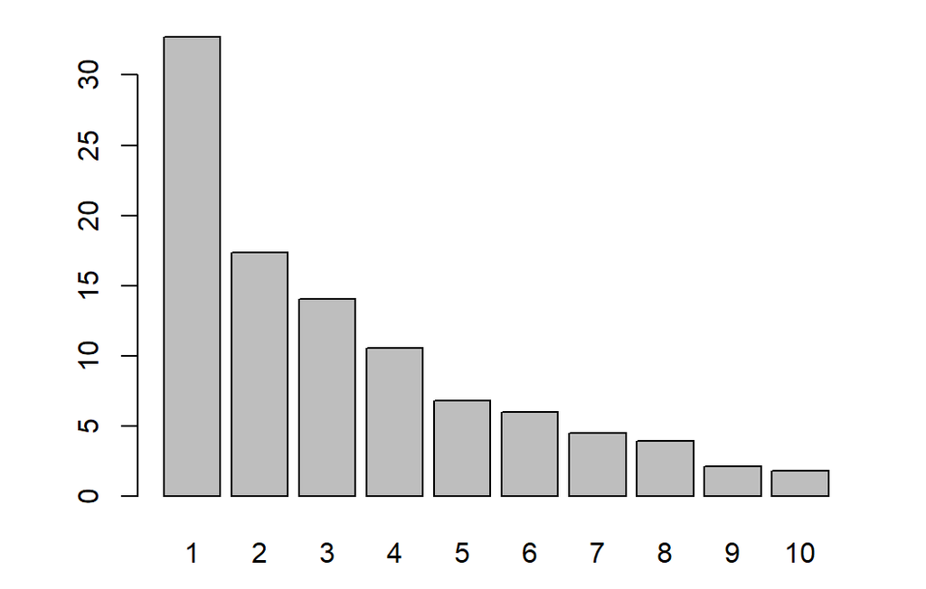

**Figure 2 - Decomposition of the total inertia on the components of the ACP**

Une estimation du nombre pertinent d’axes à interpréter suggère de restreindre l’analyse à la description des 3 premiers axes. Ces composantes révèlent un taux d’inertie supérieur à celle du quantile 0.95 de distributions aléatoires (64.14% contre 51.49%). Cette observation suggère que seuls ces axes sont porteurs d’une véritable information. En conséquence, la description de l’analyse sera restreinte à ces seuls axes.

### 3. Description du plan 1:2

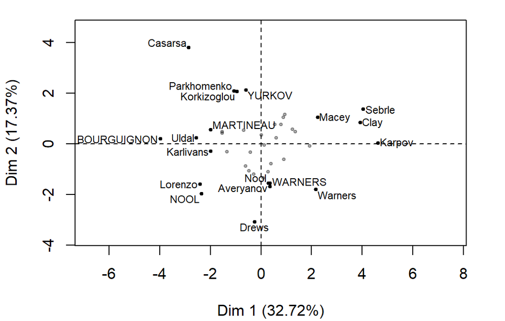

**Figure 3.1 - Graphe des individus (ACP)** *Les individus libellés sont ceux ayant la plus grande contribution à la construction du plan.*

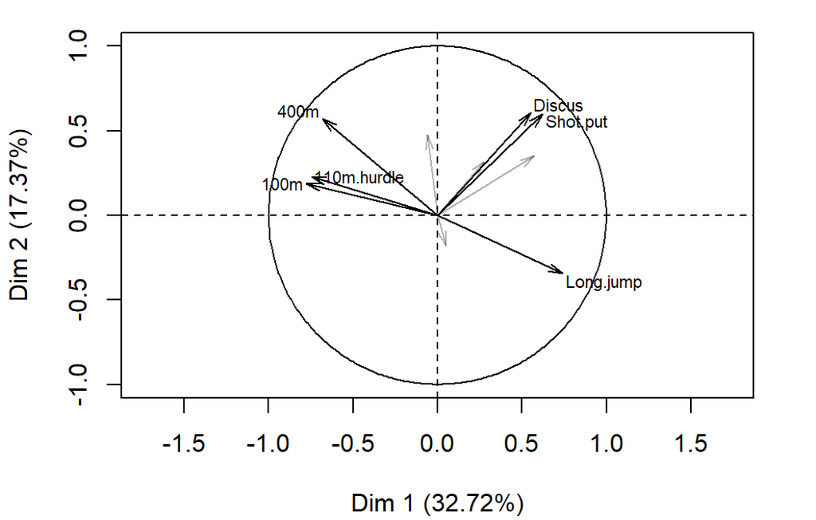

**Figure 3.2 - Graphe des variables (ACP)** *Les variables libellées sont celles les mieux représentées sur le plan.*

La **dimension 1** oppose des individus tels que *Karpov*, *Sebrle*, *Clay* et *Macey* (à droite du graphe, caractérisés par une coordonnée fortement positive sur l’axe) à des individus comme *BOURGUIGNON*, *Uldal*, *Lorenzo*, *NOOL* et *Karlivans* (à gauche du graphe, caractérisés par une coordonnée fortement négative sur l’axe).

Le groupe auquel les individus *Karpov*, *Sebrle*, *Clay* et *Macey* appartiennent (caractérisés par une coordonnée positive sur l’axe) partage :

Le groupe auquel les individus *BOURGUIGNON*, *Uldal*, *Lorenzo*, *NOOL* et *Karlivans* appartiennent (caractérisés par une coordonnées négative sur l’axe) partage :

- de fortes valeurs pour les variables *110m.hurdle* et *100m* (de la plus extrême à la moins extrême).
- de faibles valeurs pour les variables *Shot.put*, *High.jump* et *Discus* (de la plus extrême à la moins extrême).

La **dimension 2** oppose des individus tels que *Casarsa*, *YURKOV* et *Parkhomenko* (en haut du graphe, caractérisés par une coordonnées fortement positive sur l’axe) à des individus comme *Warners*, *Drews* et *WARNERS* (en bas du graphe, caractérisés par une coordonnées fortement négative sur l’axe).

Le groupe auquel les individus *Casarsa*, *YURKOV* et *Parkhomenko* appartiennent (caractérisés par une coordonnée positive sur l’axe) partage :

- de fortes valeurs pour la variable *400m*.
- de faibles valeurs pour la variable *Long.jump*.

Le groupe auquel les individus *Warners*, *Drews* et *WARNERS* appartiennent (caractérisés par une coordonnées négative sur l’axe) partage :

- de fortes valeurs pour la variable *Pole.vault*.
- de faibles valeurs pour la variable *110m.hurdle*.

### 4. Description de la dimension 3

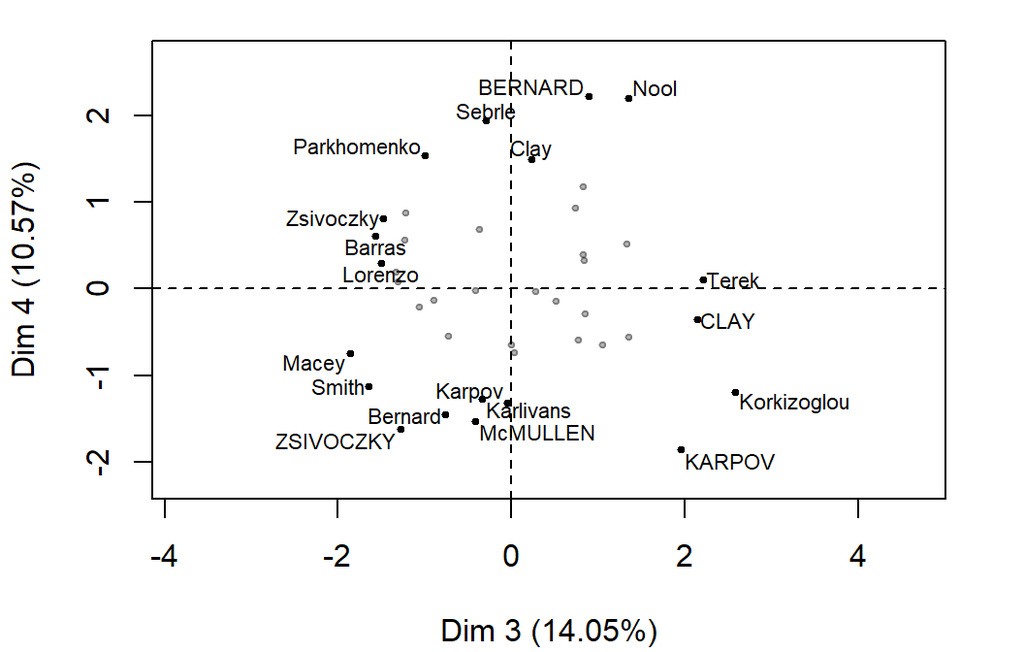

**Figure 4.1 - Graphe des individus (ACP)** *Les individus libellés sont ceux ayant la plus grande contribution à la construction du plan.*

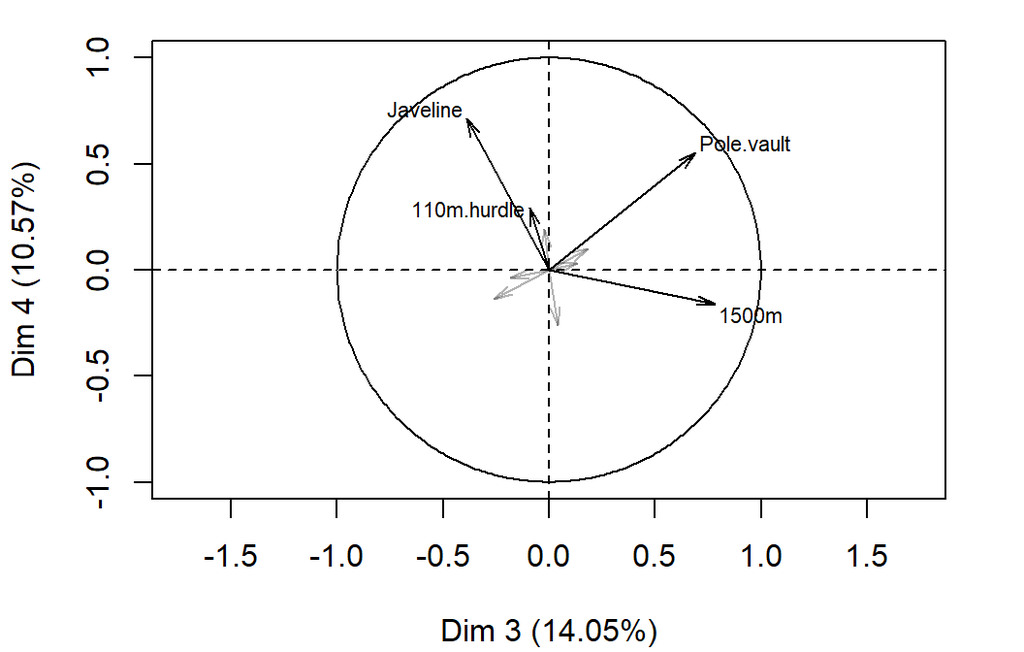

**Figure 4.2 - Graphe des variables (ACP)** *Les variables libellées sont celles les mieux représentées sur le plan.*

Le groupe auquel les individus *KARPOV*, *Korkizoglou*, *Terek* et *CLAY* appartiennent (caractérisés par une coordonnée positive sur l’axe) partage :

- de fortes valeurs pour la variable *1500m*.
- de faibles valeurs pour la variable *Javeline*.

### 5. Classification

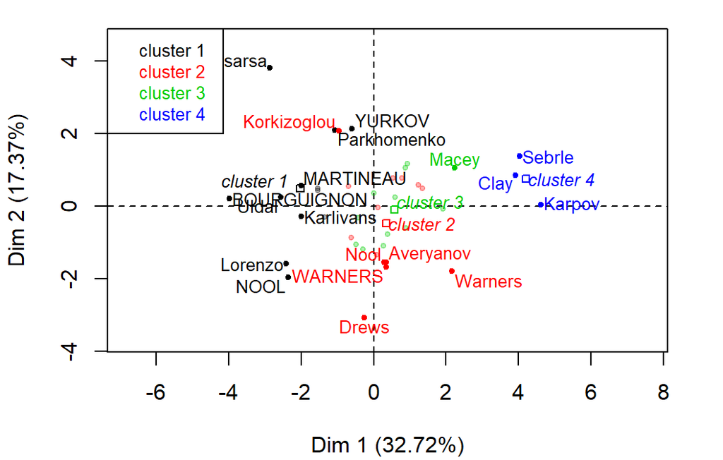

**Figure 5 - Classification Ascendante Hiérachique des individus.** *La classification réalisée sur les individus fait apparaître 4 classes.*

La **classe 1** est composée d’individus tels que *YURKOV*, *MARTINEAU*, *NOOL*, *BOURGUIGNON*, *Parkhomenko*, *Lorenzo*, *Karlivans*, *Uldal* et *Casarsa*. Ce groupe est caractérisé par :

- de fortes valeurs pour les variables *100m*, *110m.hurdle* et *400m* (de la plus extrême à la moins extrême).
- de faibles valeurs pour les variables *Long.jump* et *Shot.put* (de la plus extrême à la moins extrême).

La **classe 2** est composée d’individus tels que *WARNERS*, *Warners*, *Nool*, *Averyanov*, *Drews* et *Korkizoglou*. Ce groupe est caractérisé par :

- de fortes valeurs pour les variables *Pole.vault* et *1500m* (de la plus extrême à la moins extrême).
- de faibles valeurs pour les variables *Javeline* et *100m* (de la plus extrême à la moins extrême).

La **classe 3** est composée d’individus tels que *Macey*. Ce groupe est caractérisé par :

- de faibles valeurs pour les variables *Pole.vault* et *1500m* (de la plus extrême à la moins extrême).

La **classe 4** est composée d’individus tels que *Sebrle*, *Clay* et *Karpov*. Ce groupe est caractérisé par :

- de fortes valeurs pour les variables *Long.jump*, *Discus*, *Shot.put*, *Javeline* et *High.jump* (de la plus extrême à la moins extrême).
- de faibles valeurs pour les variables *100m*, *400m* et *110m.hurdle* (de la plus extrême à la moins extrême).

## Annexes

```
$Dim.1
$Dim.1$quanti
            correlation      p.value
Long.jump     0.7418997 2.849886e-08
Shot.put      0.6225026 1.388321e-05
High.jump     0.5719453 9.362285e-05
Discus        0.5524665 1.802220e-04
400m         -0.6796099 1.028175e-06
110m.hurdle  -0.7462453 2.136962e-08
100m         -0.7747198 2.778467e-09


$Dim.2
$Dim.2$quanti
          correlation      p.value
Discus      0.6063134 2.650745e-05
Shot.put    0.5983033 3.603567e-05
400m        0.5694378 1.020941e-04
1500m       0.4742238 1.734405e-03
High.jump   0.3502936 2.475025e-02
Javeline    0.3169891 4.344974e-02
Long.jump  -0.3454213 2.696969e-02


$Dim.3
$Dim.3$quanti
           correlation      p.value
1500m        0.7821428 1.554450e-09
Pole.vault   0.6917567 5.480172e-07
Javeline    -0.3896554 1.179331e-02
```

**Figure 6 - Liste des variables caractéristiques des dimensions de l’analyse.**

```
$quanti.var
                 Eta2      P-value
100m        0.6581552 9.668613e-09
Pole.vault  0.5712977 5.972228e-07
Long.jump   0.5293255 3.246949e-06
110m.hurdle 0.4455078 6.229435e-05
400m        0.4425235 6.859144e-05
Shot.put    0.2869412 5.393490e-03
Discus      0.2777274 6.745695e-03
1500m       0.2602251 1.022178e-02
Javeline    0.2500899 1.293207e-02
High.jump   0.2255099 2.250558e-02

$quanti
$quanti$`1`
               v.test Mean in category Overall mean sd in category
100m         4.741585        11.300833     10.99805      0.1445947
110m.hurdle  3.964894        15.060000     14.60585      0.3798903
400m         3.822084        50.686667     49.61634      1.0702051
Shot.put    -2.100392        14.056667     14.47707      0.8698116
Long.jump   -3.406381         6.998333      7.26000      0.2586450
            Overall sd      p.value
100m         0.2597956 2.120526e-06
110m.hurdle  0.4660000 7.342867e-05
400m         1.1392975 1.323286e-04
Shot.put     0.8143118 3.569438e-02
Long.jump    0.3125193 6.583024e-04

$quanti$`2`
              v.test Mean in category Overall mean sd in category
Pole.vault  4.295481         5.021429     4.762439      0.1919024
1500m       2.602164       285.612857   279.024878     12.7576030
100m       -1.969217        10.885714    10.998049      0.1539812
Javeline   -2.125561        56.091429    58.316585      4.5043580
           Overall sd      p.value
Pole.vault  0.2745887 1.743152e-05
1500m      11.5300118 9.263766e-03
100m        0.2597956 4.892823e-02
Javeline    4.7675931 3.353983e-02

```

[output cut: 16 more lines]

```
400m        -2.333955         48.12000    49.616341     0.98634004
100m        -2.745523         10.59667    10.998049     0.18080069
            Overall sd      p.value
Long.jump   0.31251927 0.0005232144
Discus      3.33639725 0.0018865229
Shot.put    0.81431175 0.0029368475
Javeline    4.76759315 0.0096869552
High.jump   0.08785906 0.0220791704
110m.hurdle 0.46599998 0.0340317657
400m        1.13929751 0.0195981038
100m        0.25979560 0.0060414576


attr(,"class")
[1] "catdes" "list "
```

**Figure 7 - Liste des variables caractéristiques des clusters de la classification.**